# Math311_final

Jackson Evans

5/25/2021

I have not given nor received any unauthorized aid on this exam. JE.

1. These data are specific to one week and therefore may not be indicative of overall hapiness levels for the individuals. They could easily be influenced by random outside factors. If we assume they are representative samples, though, we can analyse differences in happiness levels.

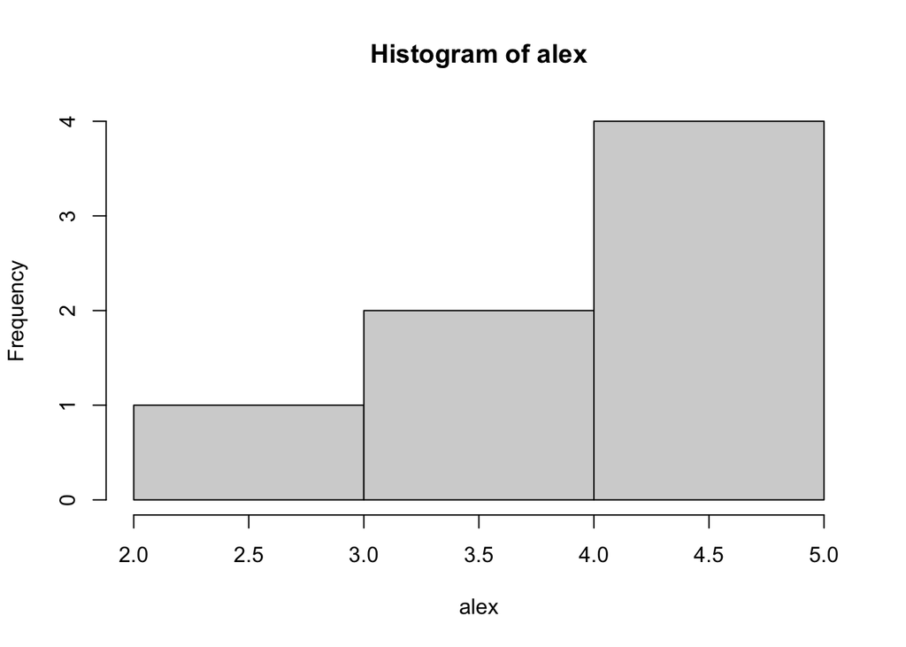

```r
alex<-c(4,3.5,5,4.5,2,5,5)
shannon<-c(2.5,3,4.5,3,1,4.5,5)
hist(alex)
```

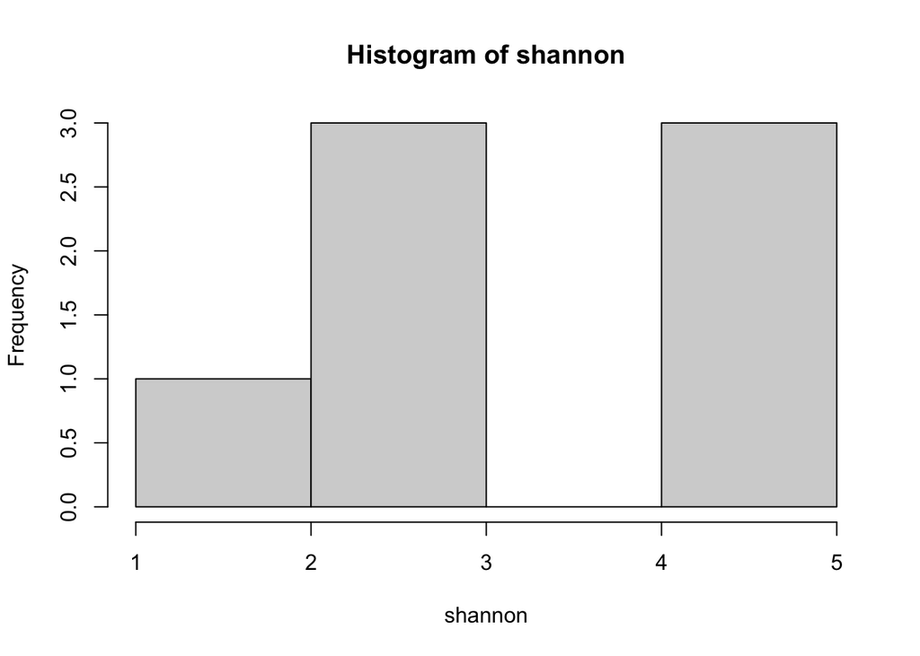

```r
hist(shannon)
```

```r
mean(alex)-mean(shannon)
```

```
## [1] 0.7857143
```

Clearly, the data are not normal - they are skewed and not unimodal. The data are very small. To do a test, though, let’s assume that the data are representative - after all they were collected from a random week. H0: mu(alex)=mu(shannon) Ha: mu(alex)=mu(shannon) There is an observed difference in the means of the collected samples: alex’s mean is 0.7857143 higher than shannon’s. Let’s do a matched pairs permutation to see if this difference is significant.

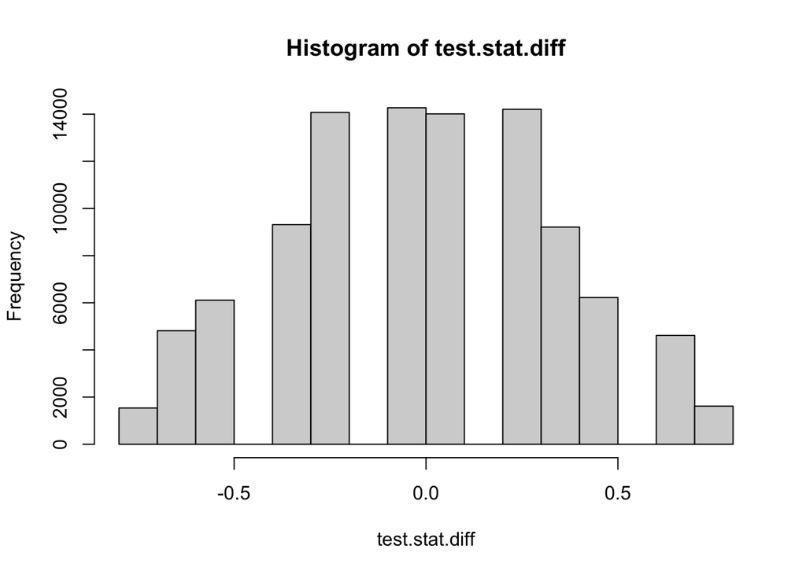

```r
alex<-c(4,3.5,5,4.5,2,5,5)
shannon<-c(2.5,3,4.5,3,1,4.5,5)

diff <- alex - shannon
actual.test.stat <- mean(diff)

test.stat.diff <- NULL
set.seed(311)
for(i in 1:100000){
  sign <- sample(c(-1,1), size = length(diff), replace = TRUE)
  random.diff <- diff*sign
  test.stat.diff[i] <- mean(random.diff)
}
#Let's look at our null distribution
hist(test.stat.diff)
```

```r
#Calculate p-value
mean(test.stat.diff >= actual.test.stat) *2
```

```
## [1] 0.0323
```

2. Let’s treat a fair die as separate from the biased die. Outcome table:

```r
tab <- matrix(c('-100 (type I)', '200 (power)', '50', '-50 (type II)'), ncol=2, byrow=TRUE)
colnames(tab) <- c('cheating','not cheating')
rownames(tab) <- c('guilty','not guilty')
tab <- as.table(tab)
tab
```

```
##            cheating      not cheating
## guilty     -100 (type I) 200 (power)
## not guilty 50            -50 (type II)
```

Based on our outcome table, we want to be correct to maximize our emotional value. So when can we be sure with the least amount of rolls? Means:

```r
fair_mean<-(1+2+3+4+5+6+7+8)/8
fair_mean
```

```
## [1] 4.5
```

```r
biased_mean<-(8*(1/2))+(1+2+3+4+5+6+7)/14
biased_mean
```

```
## [1] 6
```

So we can see that the biased die would have a mean of 6, significantly higher than 4.5. We are trying to figure out n. We may have to try ranges of alpha and n values. Let’s find standard deviations

```r
#fair die
fair_mean<-(1+2+3+4+5+6+7+8)/8
fair_sd<-sqrt((1/8)*(1+2^2 + 3^2 + 4^2 + 5^2 + 6^2 + 7^2 + 8^2) - 4.5)
biased_mean<-(8*(1/2))+(1+2+3+4+5+6+7)/14
biased_sd<-sqrt((1/14)*(1+2^2 + 3^2 + 4^2 + 5^2 + 6^2 + 7^2)+(8^2)/2 - 6)
```

Let our null hypothesis be that the die is fair (innocent until proven guilty). Then our null distribution has mean 4.5 and standard deviation sqrt(21). Using an alpha value of 0.01, to minimize the chance of a -100 value and increase likelihood of a +50 outcome (.99 if the die is fair) we can plot many different probabilities of a type II error and power. Based on our hypotheses, the power correlates to a correct accusation of cheating (+200) whereas 1-power = P(type II error) correlates to -50 points. We also must factor in -1 for every die rolled.

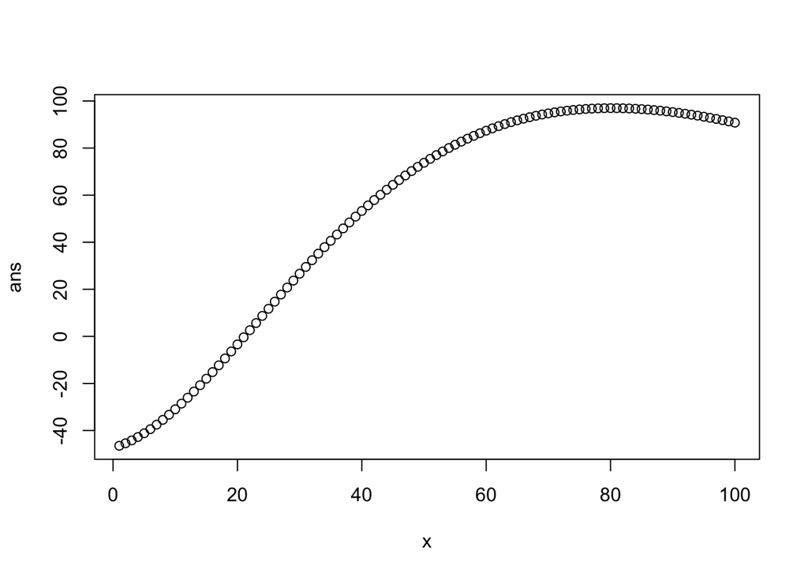

```r
x<-1:100
ans<-NULL
for(i in 1:length(x)){
  n<-i
  distance<-4.5-qnorm(0.005, 4.5, sqrt(21)/sqrt(n))
  power<-pnorm(4.5-distance,6,sqrt(21)/sqrt(n)) + pnorm(4+distance,6,sqrt(21)/sqrt(n), lower.tail = FALSE)
  ans[i]<-200*power -n -50*(1-power) #what we want to maximize
}
plot(x,ans)
```

```r
which.max(ans)
```

```
## [1] 80
```

For an alpha value of 0.01, the we have a maximum at 80 rolls. Let’s try different alpha values. We will run a nested for loop checking different alpha values as well as the different number of rolls above. We also change our emotional change expression to represent all four outcomes.

```r
alpha_vals<-1-.01*seq(from=80, to=99.99, by=0.01)
x<-1:100
maxes<-NULL
for(i in 1:length(alpha_vals)){
  ans<-NULL
  for(j in 1:length(x)){
    distance<-4.5-qnorm(alpha_vals[i], 4.5, sqrt(21)/sqrt(j))
    power<-pnorm(4.5-distance,6,sqrt(21)/sqrt(j)) + pnorm(4+distance,6,sqrt(21)/sqrt(j), lower.tail = FALSE)
    ans[j]<-200*power -j -50*(1-power) -100*(alpha_vals[i]) + 50*(1-alpha_vals[i]) #what we want to maximize - different from before as we are factoring type one errors.
  }
  maxes[i]<-max(ans)
}
which.max(maxes)
```

```
## [1] 829
```

```r
alpha_vals[829]
```

```
## [1] 0.1172
```

This says that the 829th value contains the maximum. Let’s run our maximizing function for the corresponding alpha=0.1172

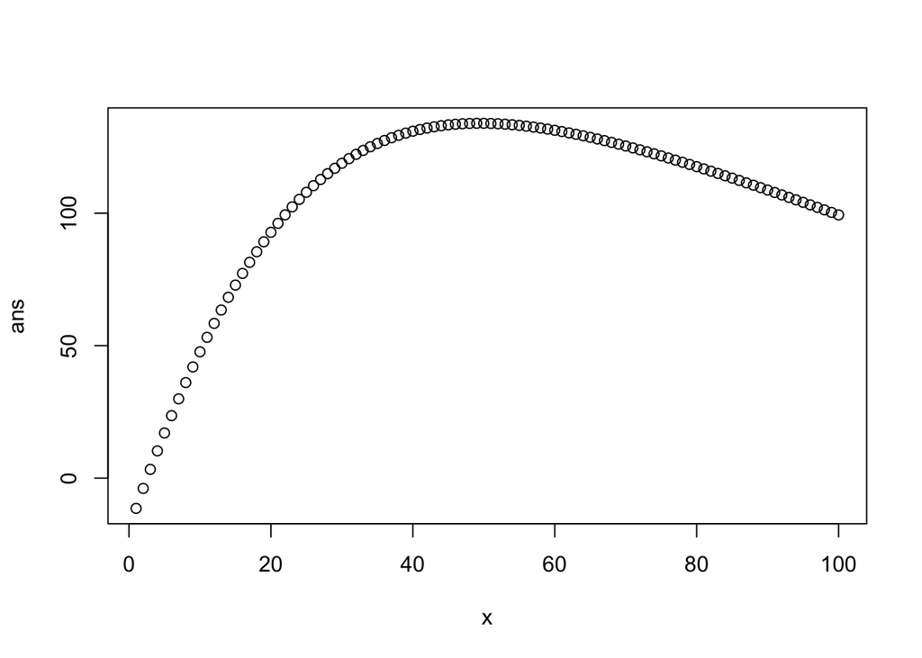

```r
x<-1:100
ans<-NULL
for(i in 1:length(x)){
  n<-i
  distance<-4.5-qnorm(0.0586, 4.5, sqrt(21)/sqrt(n))
  power<-pnorm(4.5-distance,6,sqrt(21)/sqrt(n)) + pnorm(4+distance,6,sqrt(21)/sqrt(n), lower.tail = FALSE)
  ans[i]<-200*power -n -50*(1-power) #what we want to maximize
}
plot(x,ans)
```

```r
max(ans)
```

```
## [1] 133.9341
```

```r
which.max(ans)
```

```
## [1] 49
```

This shows that to maximize the emotional change, we should use an alpha value of 0.1172 and roll 49 times. This would give us an expected emotional change of +133.9341. So we should roll 49 times.

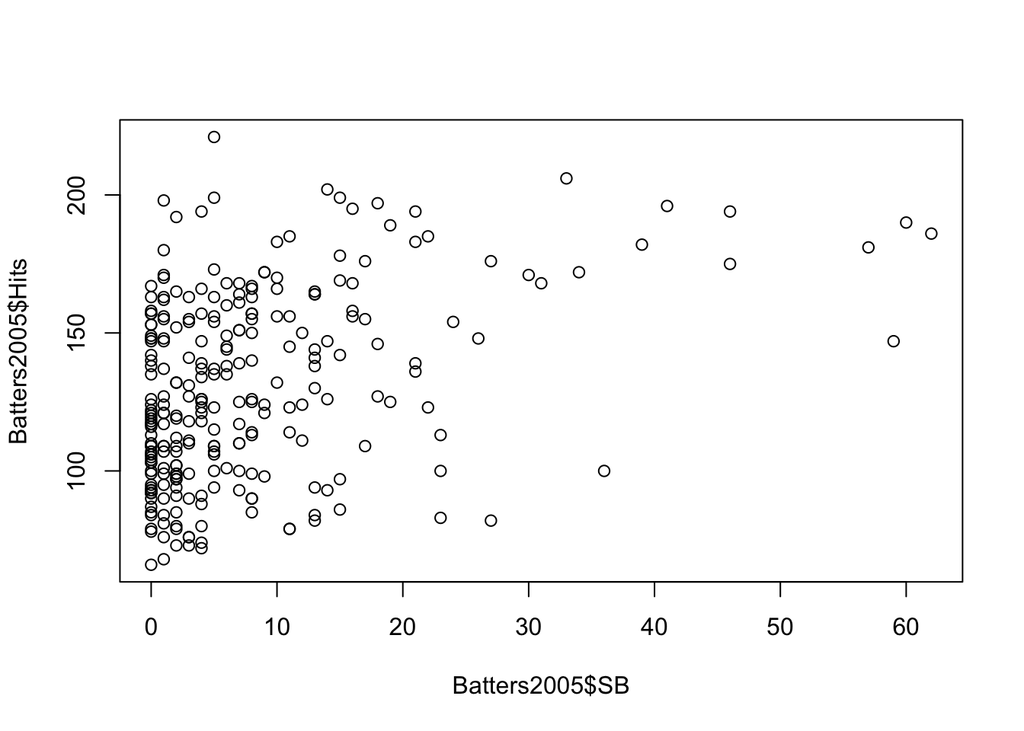

```r
library(resampledata)
plot(Batters2005$SB,
     Batters2005$Hits)
```

The assumptions for building a linear model are that there is a linear relationship between x and y, the x values are fixed, the residuals are independent, the residuals have constant variance and are normally distributed. There is potentially a linear relationship based on the graph above, but that claim is tenuous.

```r
#Build our linear model
model1<-lm(Hits ~ SB, data = Batters2005)
model1
```

```
##
## Call:
## lm(formula = Hits ~ SB, data = Batters2005)
##
## Coefficients:
## (Intercept)           SB
##     120.083        1.256
```

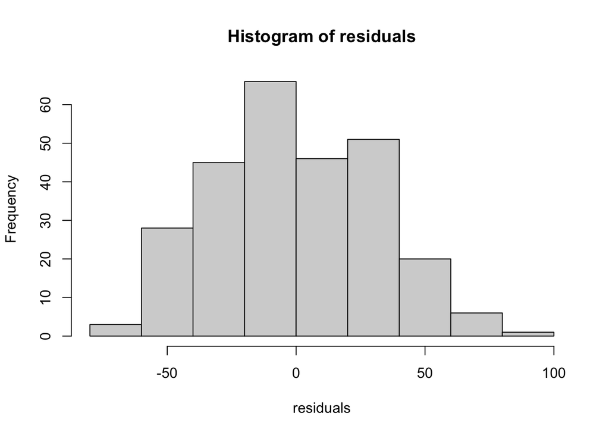

```r
#Build a residual vs fitted plot
residuals<-resid(model1)
hist(residuals)
```

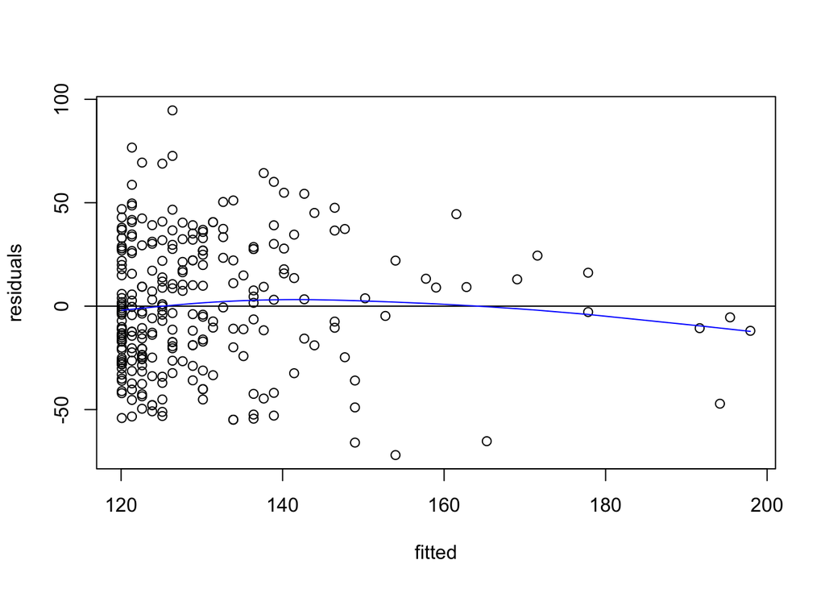

```r
fitted<-predict(model1) #predicted

plot(fitted, residuals)
abline(h=0)
lines(smooth.spline(fitted, residuals,
      df = 3), col="blue")
```

The residual vs fitted plot above shows the residuals seem centered around 0 without positive or negative skew, but the variance does not seem normal. There is slight curvature indicated by the blue line. Overall this isn’t a horrible model - the variance isn’t too bad and the mean is fairly accurate. There could be some linear relation in the initial plot, but there seeems to be too many irregularities to confidently build a simply linear regression model.

```r
model1<-lm(Hits ~ SB, data = Batters2005)
model1
```

```
##
## Call:
## lm(formula = Hits ~ SB, data = Batters2005)
##
## Coefficients:
## (Intercept)           SB
##     120.083        1.256
```

```r
summary(model1)
```

```
##
## Call:
## lm(formula = Hits ~ SB, data = Batters2005)
##
## Residuals:
##     Min      1Q  Median      3Q     Max
## -71.983 -24.011  -2.716  26.411  94.639
##
## Coefficients:
##             Estimate Std. Error t value Pr(>|t|)
## (Intercept) 120.0833     2.3877   50.29  < 2e-16 ***
## SB            1.2555     0.1807    6.95 2.86e-11 ***
## ---
## Signif. codes:  0 '***' 0.001 '**' 0.01 '*' 0.05 '.' 0.1 ' ' 1
##
## Residual standard error: 31.29 on 264 degrees of freedom
##   (1 observation deleted due to missingness)
## Multiple R-squared:  0.1547, Adjusted R-squared:  0.1515
## F-statistic:  48.3 on 1 and 264 DF,  p-value: 2.858e-11
```

4. The poisson distribution’s population variance is modeled by mu, the same as the mean. The bootstrap t confidence interval should to a better job almost always than the bootrap percentile interval. For small samples, the bootstrap percentile interval is often too narrow, but starts to handle skewness well for larger n. However, the bootstrap t is the best interval for almost all n, and handles skewness better than all other intervals. The coverage rates for the bootstrap t confidence interval will be proximate to the desired confidence level for almost all n, with a small error for small n. Alternatively the bootstrap percentile interval has a relatively low coverage rate for small n and slowly converges towards the desired confidence level. Sampling poisson variances for large n sees the variances emulate the cdf of the poisson distribution, same for the pdf. This means that the pdf of the estimation for population variance will be unimodal and somewhat symmetrical, although the poisson distribution will provide some skew. This means the bootstrap t-confidence interval will be superior to the bootstrap percentile interval for small and medium n, but they will be mostly the same for large n as they both converge to the desired confidence level. To test this, lets use a poisson(10) distribution.

```r
#Boot for pop variance of poisson(10)
boot_confidence<-NULL
lambda<-10
#change confidence level and n
confidence_level<-.90
confidence_tail<-(1-confidence_level)/2
n<-10
for(i in 1:10000){
  pois_dist<-rpois(n,lambda)
  boot<-sample(pois_dist, size=n, replace=TRUE)

  boot_low_bound<-quantile(boot, confidence_tail)
  boot_up_bound<-quantile(boot, confidence_tail+confidence_level)
  if(var(pois_dist)>boot_low_bound){
    if(var(pois_dist)<boot_up_bound){
      boot_confidence[i]<-TRUE
    } else{
      boot_confidence[i]<-FALSE
    }
  } else{
    boot_confidence[i]<-FALSE
  }
}
boot_coverage_rate<-mean(boot_confidence)
boot_coverage_rate
```

```
## [1] 0.5513
```

```r
#boot t- for pop variance of poisson(10)
boot_t_confidence<-NULL
lambda<-10
ans<-NULL
#change confidence level and n
confidence_level<-.90
confidence_tail<-(1-confidence_level)/2
n<-10
for(i in 1:10000){
  pois_dist<-rpois(n,lambda)
  boot<-sample(pois_dist, size=n, replace=TRUE)

  #boot-t
  ans[i] <- (var(boot)-lambda)/(sd(boot)/sqrt(n))
  x_bar <- var(boot)#as mean and var are same for poisson
  boott_low_bound<- var(boot) - quantile(ans, confidence_level+confidence_tail)*sd(boot)/sqrt(n)
  boott_up_bound<- var(boot) - quantile(ans, confidence_tail)*sd(boot)/sqrt(n)

  if(lambda>boott_low_bound){
    if(lambda<boott_up_bound){
      boot_t_confidence[i]<-TRUE
    } else{
      boot_t_confidence[i]<-FALSE
    }
  } else{
    boot_t_confidence[i]<-FALSE
  }
}
boott_coverage_rate<-mean(boot_t_confidence)
boott_coverage_rate
```

```
## [1] 0.8972
```

The above code shows how inaccurate bootstrapping is for small n, whereas the bootstrap t is very close. The bootstrap coverage is only 55% whereas the bootstrap t coverage is almost exactly our desired confidence leve of 90%. Then as n increases,

```r
#Boot for pop variance of poisson(10)
boot_confidence<-NULL
lambda<-10
#change confidence level and n
confidence_level<-.90
confidence_tail<-(1-confidence_level)/2
n<-100
for(i in 1:10000){
  pois_dist<-rpois(n,lambda)
  boot<-sample(pois_dist, size=n, replace=TRUE)

  boot_low_bound<-quantile(boot, confidence_tail)
  boot_up_bound<-quantile(boot, confidence_tail+confidence_level)
  if(var(pois_dist)>boot_low_bound){
    if(var(pois_dist)<boot_up_bound){
      boot_confidence[i]<-TRUE
    } else{
      boot_confidence[i]<-FALSE
    }
  } else{
    boot_confidence[i]<-FALSE
  }
}
boot_coverage_rate<-mean(boot_confidence)
boot_coverage_rate
```

```
## [1] 0.9976
```

```r
#boot t- for pop variance of poisson(10)
boot_t_confidence<-NULL
lambda<-100
ans<-NULL
#change confidence level and n
confidence_level<-.90
confidence_tail<-(1-confidence_level)/2
n<-100
for(i in 1:10000){
  pois_dist<-rpois(n,lambda)
  boot<-sample(pois_dist, size=n, replace=TRUE)

  #boot-t
  ans[i] <- (var(boot)-lambda)/(sd(boot)/sqrt(n))
  x_bar <- var(boot)#as mean and var are same for poisson
  boott_low_bound<- var(boot) - quantile(ans, confidence_level+confidence_tail)*sd(boot)/sqrt(n)
  boott_up_bound<- var(boot) - quantile(ans, confidence_tail)*sd(boot)/sqrt(n)

  if(lambda>boott_low_bound){
    if(lambda<boott_up_bound){
      boot_t_confidence[i]<-TRUE
    } else{
      boot_t_confidence[i]<-FALSE
    }
  } else{
    boot_t_confidence[i]<-FALSE
  }
}
boott_coverage_rate<-mean(boot_t_confidence)
boott_coverage_rate
```

```
## [1] 0.9003
```

Bootstrapping is still unreliable, whereas our bootstrap t is consistently accurate. Therefore the bootstrap t-confidence interval is better for all n.

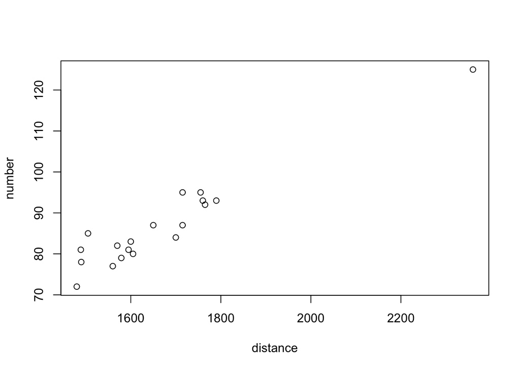

```r
distance<-c(1480, 1490, 1489, 1505, 1560, 1570, 1595, 1579, 1600, 1605, 1650, 1700, 1715, 1715, 1755, 1760, 1765, 1790, 2360)
number<-c(72,78,81,85,77,82,81,79,83,80,87,84,87,95,95,93,92,93,125)
sprints<-data.frame(distance, number)
plot(sprints)
```

```r
sprint_model<-lm(number ~ distance, data = sprints)
sprint_model
```

```
##
## Call:
## lm(formula = number ~ distance, data = sprints)
##
## Coefficients:
## (Intercept)     distance
##     -5.2624       0.0552
```

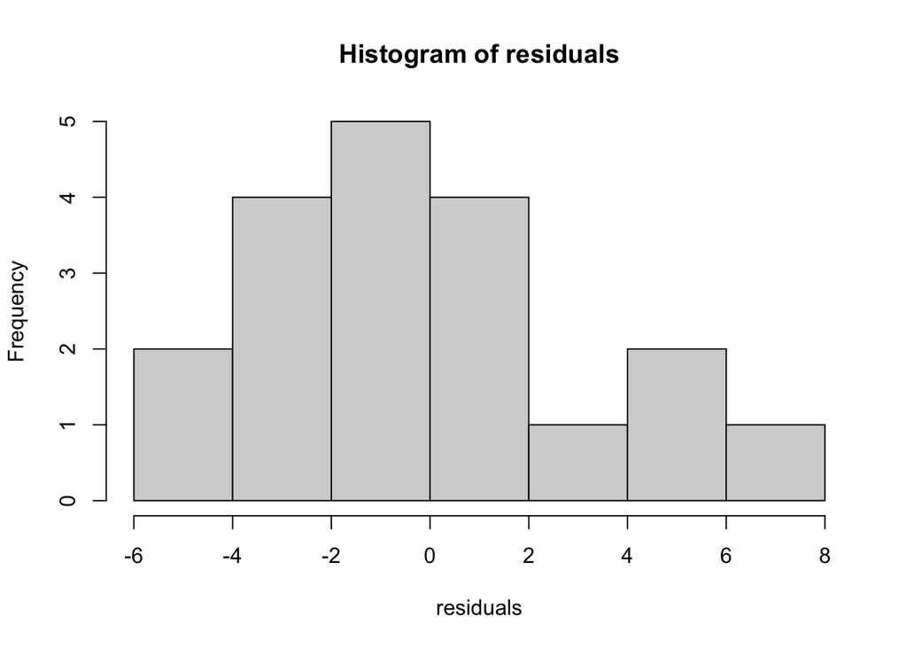

```r
#Build a residual vs fitted plot
residuals<-resid(sprint_model)
hist(residuals)
```

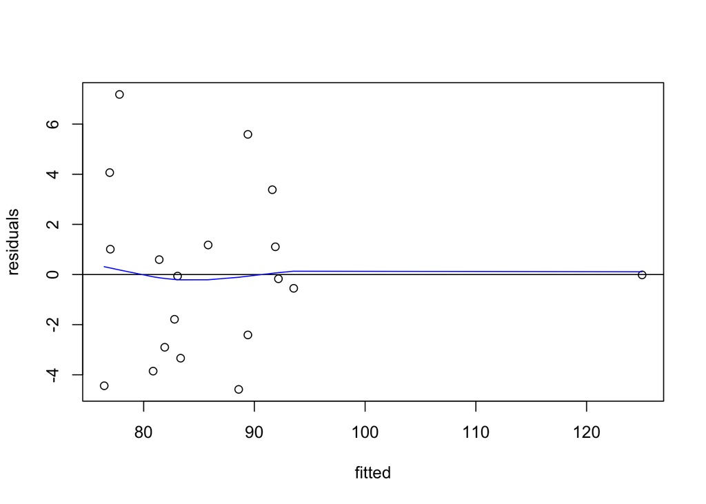

```r
fitted<-predict(sprint_model) #predicted

plot(fitted, residuals)
abline(h=0)
lines(smooth.spline(fitted, residuals,
      df = 3), col="blue")
```

```r
summary(sprint_model)
```

```
##
## Call:
## lm(formula = number ~ distance, data = sprints)
##
## Residuals:
##     Min      1Q  Median      3Q     Max
## -4.5821 -2.6564 -0.0618  1.1419  7.1824
##
## Coefficients:
##             Estimate Std. Error t value Pr(>|t|)
## (Intercept) -5.26236    6.89865  -0.763    0.456
## distance     0.05520    0.00411  13.431 1.76e-10 ***
## ---
## Signif. codes:  0 '***' 0.001 '**' 0.01 '*' 0.05 '.' 0.1 ' ' 1
##
## Residual standard error: 3.423 on 17 degrees of freedom
## Multiple R-squared:  0.9139, Adjusted R-squared:  0.9088
## F-statistic: 180.4 on 1 and 17 DF,  p-value: 1.764e-10
```

Based on our model, our line is y=0.0552x-5.2624. Based on this, if the average sprint distance is 2000:

```r
.0552*2000-5.2624
```

```
## [1] 105.1376
```

we would expect about 105 sprints. The residuals are certainly distributed with a mean of 0, but their variance is a bit off. Our r squared value is around 91%, which should explain about 91% of the variance in the data. This is pretty good. However, we must acknowledge our outlier point. While the point is certainly an outlier in scale, it seems fairly in line with our estimate. To check, let’s remove it and build a linear model and check to see if our estimation changes.

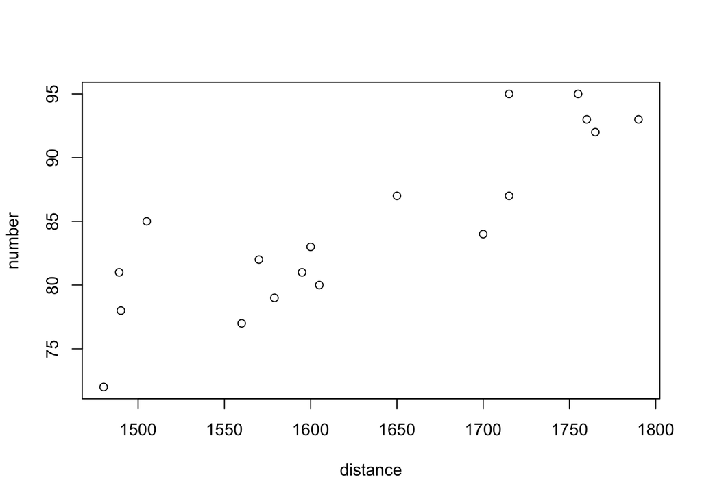

```r
distance<-c(1480, 1490, 1489, 1505, 1560, 1570, 1595, 1579, 1600, 1605, 1650, 1700, 1715, 1715, 1755, 1760, 1765, 1790)
number<-c(72,78,81,85,77,82,81,79,83,80,87,84,87,95,95,93,92,93)
sprints<-data.frame(distance, number)
plot(sprints)
```

```r
sprint_model<-lm(number ~ distance, data = sprints)
sprint_model
```

```
##
## Call:
## lm(formula = number ~ distance, data = sprints)
##
## Coefficients:
## (Intercept)     distance
##    -5.36207      0.05526
```

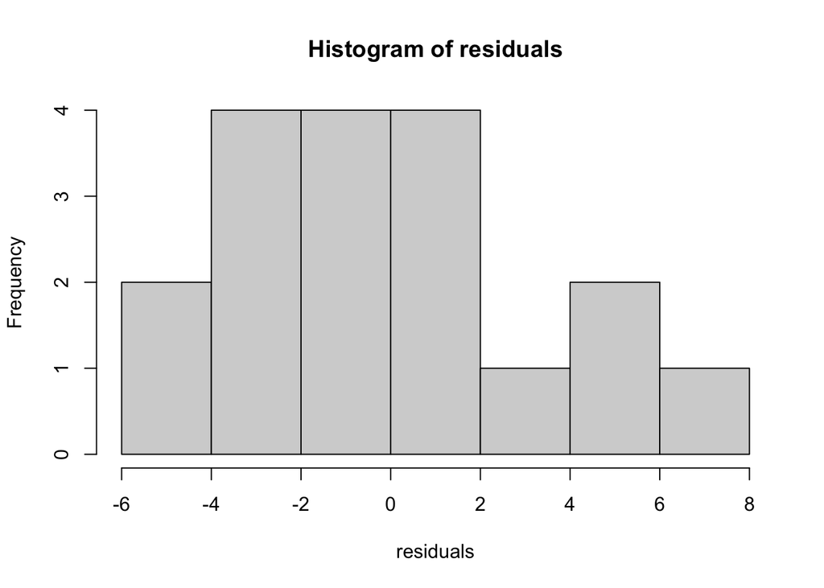

```r
#Build a residual vs fitted plot
residuals<-resid(sprint_model)
hist(residuals)
```

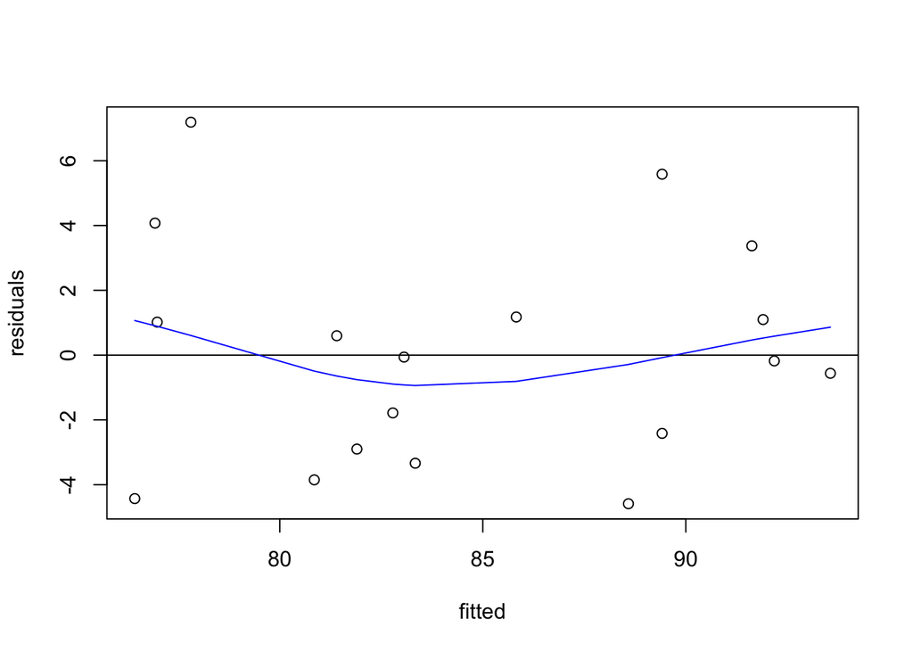

```r
fitted<-predict(sprint_model) #predicted

plot(fitted, residuals)
abline(h=0)
lines(smooth.spline(fitted, residuals,
      df = 3), col="blue")
```

```r
summary(sprint_model)
```

```
##
## Call:
## lm(formula = number ~ distance, data = sprints)
##
## Residuals:
##     Min      1Q  Median      3Q     Max
## -4.5874 -2.7794 -0.1202  1.1561  7.1892
##
## Coefficients:
##              Estimate Std. Error t value Pr(>|t|)
## (Intercept) -5.362073  13.299855  -0.403    0.692
## distance     0.055264   0.008148   6.782  4.4e-06 ***
## ---
## Signif. codes:  0 '***' 0.001 '**' 0.01 '*' 0.05 '.' 0.1 ' ' 1
##
## Residual standard error: 3.529 on 16 degrees of freedom
## Multiple R-squared:  0.7419, Adjusted R-squared:  0.7258
## F-statistic:    46 on 1 and 16 DF,  p-value: 4.402e-06
```

The plot looks linear even without the outlier point. In this adjusted model, we see some curvature in the residuals plot, along with a significant drop in our r squared value, down to 74%. Our new line, however, is y=0.05526x - 5.36207. Plugging in 2000 for x gives us a new estimate of:

```r
0.05526*2000 - 5.36207
```

```
## [1] 105.1579
```

The new estimate is essentially the same, 105 sprints. Regardless, our estimate is 105 sprints.

3. To find a confidence interval, let’s bootstrap. We need to remove the outlier as we are permuting rows and the outlier would significantly alter the rest of the data. We already know that the removal of the outlier doesn’t change the predicted line.

```r
distance<-c(1480, 1490, 1489, 1505, 1560, 1570, 1595, 1579, 1600, 1605, 1650, 1700, 1715, 1715, 1755, 1760, 1765, 1790)
number<-c(72,78,81,85,77,82,81,79,83,80,87,84,87,95,95,93,92,93)
sprints<-data.frame(distance, number)
ans<-NULL
n<-nrow((sprints))
set.seed(310)
for(i in 1:10000){
  index <- sample(n, replace = TRUE)
  new<-sprints[index,]
  new_model<-lm(number ~ distance, data = new)
  ans[i]<-new_model$coefficients[[2]]
}

quantile(ans,c(0.025, .975))
```

```
##       2.5%      97.5%
## 0.03822063 0.07224524
```